# COMPSCI 527 Homework 3

## Homework Submission Workflow

When you submit your work, follow the instructions on the [submission workflow page](https://www.cs.duke.edu/courses/spring24/compsci527/homework/workflow.html) **scrupulously** for full credit.

### Problem 0 (3 points)

Is this assignment properly formatted in the PDF submission, and did you tell Gradescope accurately where each answer is?

#### Note

This question requires no explicit answer from you, and no space is provided for an answer in the template file.

However, the rubric entry for this problem in Gradescope will be used to decuct points for poor formatting of the assignment (PDF is not readable, code or text is clipped, math is not typeset, ...) and for incorrect indications in Gradescope for the location of each answer.

Sorry we have to do this, but poor formatting and bad answer links in Gradescope make our grading much harder.

## Part 1: Basics of Image Motion

A ball thrown in the air follows a parabolic trajectory under the effect of gravity. Atmospheric effects are negligible. As a result, the horizontal velocity of the ball is constant and its vertical motion undergoes constant acceleration downwards. The ball is filmed by a static black-and-white camera which sees the whole trajectory from the side (that is, the image plane of the camera is parallel to the plane that contains the trajectory). The ball translates and does not spin. As a consequence, its image moves by a pure translation in the image plane. That is, all points visible on the ball move by the same image motion.

The center of the ball is at position $\mathbf{x}(t)$ in the image at time $t$. The components $x(t)$ and $y(t)$ of $\mathbf{x}(t)$ are measured in pixels relative to the initial position of the ball in the image when recording is started at time $t=0$. Specifically, $x(t)$ is measured horizontally (increasing left-to-right) and $y(t)$ vertically (increasing top-down).

The components of $\mathbf{x}(t)$ are found to be

$$ \begin{eqnarray*} x(t) &=& a t \\ y(t) &=& b t + c t^2 \end{eqnarray*} $$

where

$$ \begin{eqnarray*} \mathbf{a} &=& (a, b) = (10, -20)\; \mbox{pixels per frame}\\ c &=& 12\; \mbox{pixels per frame squared.} \end{eqnarray*} $$

### Problem 1.1 (Exam Style)

What is the image motion field $\mathbf{u}(t)$ at image position $\mathbf{x}(t)$ at time $t$, measured in pixels per frame? Give both formulas for the two components $u(t)$ and $v(t)$ of $\mathbf{u}(t)$ in terms of $a, b, c, t$ and their numerical values for $t = 0$ frames and for $t = 1$ frame. Include units of measure for your numerical answers.

### Problem 1.2 (Exam Style)

The image brightness pattern $e(\mathbf{x}, t)$ on the ball is found to have a spatial gradient $\nabla e$ at the center $\mathbf{x}(t)$ of the ball. This gradient is unchanged over time and the numerical values of its components are

$$ \begin{eqnarray*} e_x &=& \frac{\partial e}{\partial x} = 3\; \text{gray levels per pixel} \\ e_y &=& \frac{\partial e}{\partial y} = 4\; \text{gray levels per pixel.} \end{eqnarray*} $$

A "gray level" is whatever unit brightness is measured in. For instance, you could think of it as a real number between 0 and 1, or between 0 and 255.

Write a formula in terms of $a, b, c, t, e_x, e_y$ for the normal component $\omega(t)$ of the motion field at position $\mathbf{x}(t)$ and time $t$. Then give the value of $\omega(0)$. Include the unit of measure for your numerical answer.

#### Note

- By its definition, the normal component of the motion field is a signed scalar.

### Problem 1.3 (Exam Style)

Write a formula in terms of $a, b, c, t, e_x, e_y$ for the partial derivative $$ e_t = \frac{\partial e}{\partial t} $$ of image brightness with respect to time when measured at image position $\mathbf{x}(t)$ at time $t$.

Then give the numerical value of this partial derivative at time $t=0$. Include the unit of measure for your numerical answer.

### Problem 1.4 (Exam Style)

Suppose that the spatial brightness gradient $\nabla e'$ at a different point $\mathbf{x}'(t)$ on the ball is also unchanging, and equal to $\nabla e' = (e'_x, e'_y)^T = (8, -6)^T$. Since the ball translates without spin, the motion field $\mathbf{u}'(t)$ of of this new point is the same as the motion field $\mathbf{u}(t)$ of $\mathbf{x}$ for all values of $t$.

- Give the numerical value $e'_t$ of the temporal derivative of $e'$ with respect to $t$ for this new point $\mathbf{x}'(t)$ at time $t=0$.
- Pretend that you do not know the true motion field at time $t=0$. Instead, assume that you are *given* the six values $e_x, e_y, e_t, e'_x, e'_y, e'_t$. The spatial gradient values are as given above, and the temporal derivatives are the values you computed earlier at time $t=0$. Show how you can recover $\mathbf{u}(0)$ from these six values and give the numerical values of the components $u, v$ of $\mathbf{u}(0)$ that result from your calculations.

#### Note

You may want to check for consistency with previous answers. Do *not* show that check.

## Part 2: Exact World and Camera Simulation

In this part we use a virtual world and camera, which can be retrieved as follows.

```python
import urllib.request
import ssl
from os import path as osp
import shutil


def retrieve(file_name, semester='spring24', homework=3):
    if osp.exists(file_name):
        print('Using previously downloaded file {}'.format(file_name))
    else:
        context = ssl._create_unverified_context()
        fmt = 'https://www2.cs.duke.edu/courses/{}/compsci527/homework/{}/{}'
        url = fmt.format(semester, homework, file_name)
        with urllib.request.urlopen(url, context=context) as response:
            with open(file_name, 'wb') as file:
                shutil.copyfileobj(response, file)
        print('Downloaded file {}'.format(file_name))
```

```python
retrieve('ideal.py')
```

```
Downloaded file ideal.py
```

```python
from autograd import numpy as np
from matplotlib import pyplot as plt
from ideal import camera, world, make_image
from ideal import motion_field, show_field, stats
from ideal import displacement, show_image_pair
```

Now let's make a frame and its spatial gradient:

```python
frame_number_0 = 0.
image_0, image_0_gradient = make_image(frame_number_0, camera, world, grad=True)
```

Let's see what they look like:

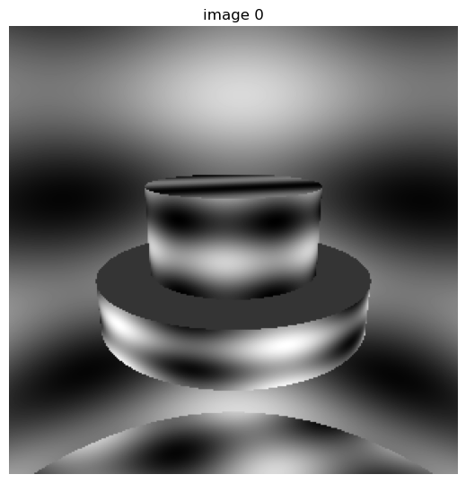

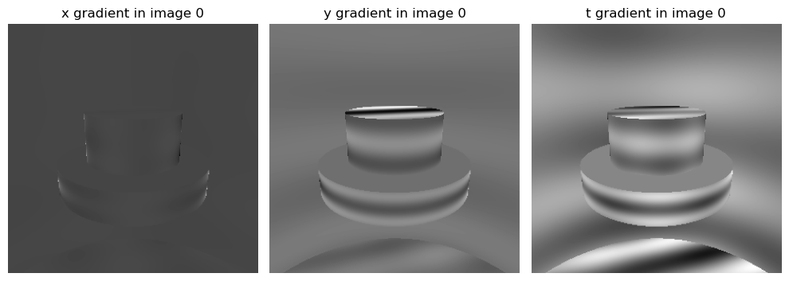

```python
show_image_pair(image_0, None)

plt.figure(figsize=(10, 3.7), tight_layout=True)
for index, coordinate in ((0, 'x'), (1, 'y'), (2, 't')):
    plt.subplot(1, 3, index + 1)
    plt.imshow(image_0_gradient[:, :, index], cmap='gray')
    plt.axis('off')
    plt.title('{} gradient in image 0'.format(coordinate))
plt.show()
```

What happened here is a luxury we do not have in the real world. First, the world is synthetic: An object that looks a bit like a bolt or a hat is placed in the middle of a cylindrical room. Most surfaces have a smooth texture on them, and everything is designed so that appearance is exactly constant as the virtual camera moves around. This type of simulation is not unusual, as this is what computer graphics does all the time.

More importantly, however, everything is known analytically, including the shapes of all surfaces and all surface texture patterns. In contrast, computer graphics wuold represent shapes with a point cloud and a triangular mesh, and then shade the triangles with some shading algorithm. Look at `ideal.py` if you want to see how an analytic world can be made.

Because of this, we can think of perspective projection (the process by which a camera creates images of the world) as a function $e(x, y, t)$ where $x, y$ are image coordinates, $t$ is time, and $e$ is image brightness. Variable $x$ goes left to right and variable $y$ goes top-bottom, and the origin is the upper-left corner of the image.

We can then use `autograd` to differentiate the function $e(x, y, t)$ exactly (to within machine precision; this *caveat* is henceforth implied). This has two advantages:

- We can compute images at arbitrary resolution both in space ($x, y$) and time ($t$).
- We get *exact* values for the spatial gradient $\nabla e$ and the partial time derivative $e_t$, again at arbitrary resolution.

Obviously you cannot do this with a real camera. This ideal, artificial setup lets you compare motion estimates with the ground truth and work in an environment where everything is tightly under control.

Specifically, in the code provided, the virtual camera rotates on a circle around the virtual object. The circle is in a tilted plane, so from the object's point of view the camera looks like the sun that rises and sets. The camera always points toward the centroid of the object, so the object remains in the field of view.

We can then use automatic differentiation (`autograd`, discussed in a previous assignment) to compute the true motion field: Start with image point coordinates $\mathbf{p}$ in `image_0`, trace the projection ray of $\mathbf{p}$ outwards in space to see where it intersects a surface in the world to find the world point $\mathbf{P}$ that projects to $\mathbf{p}$, and then invert the process to compute image coordinates $x, y = \pi(\mathbf{P}, t)$, where $\pi$ is the perspective projection function.

Of course you get $\mathbf{p}$ back with this process. However, we can now use `autograd` again by keeping the world points $\mathbf{P}$ fixed and compute the derivatives of the image $x, y$ corodinates for each point as a function of $t$ as the camera moves. These derivatives are the exact true motion field:

```python
u = motion_field(frame_number_0, camera, world)
```

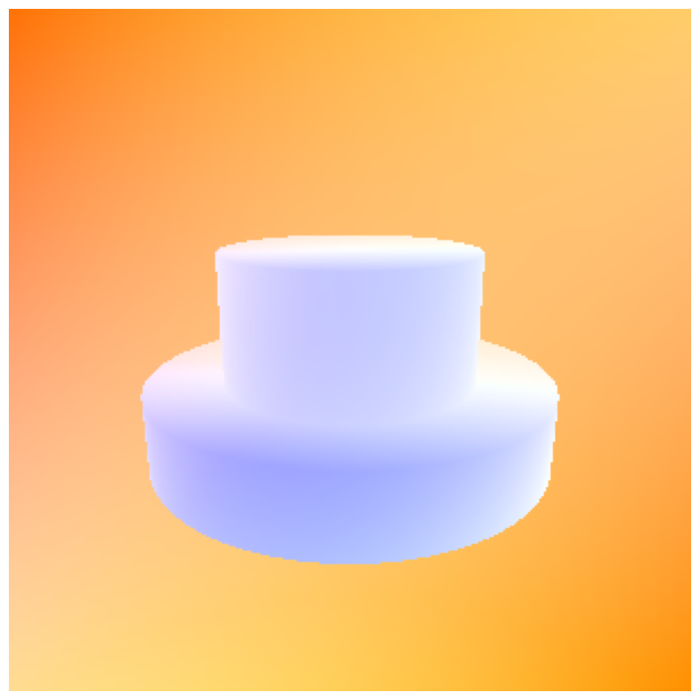

```
Statistics of the motion field magnitude in pixels per frame:
minimum: 0.009181, maximum: 1.234, mean absolute value: 0.6478, standard deviation: 0.252
```

```python
field_image = show_field(u)
stats(np.linalg.norm(u, axis=2), 'motion field magnitude in pixels per frame')
```

We can also compute the true displacement field between `image_0` and another image, say 10 frames later, display it, and compute its statistics:

```python
frame_delta = 10
frame_number_1 = frame_number_0 + frame_delta
image_1 = make_image(frame_number_1, camera, world)
```

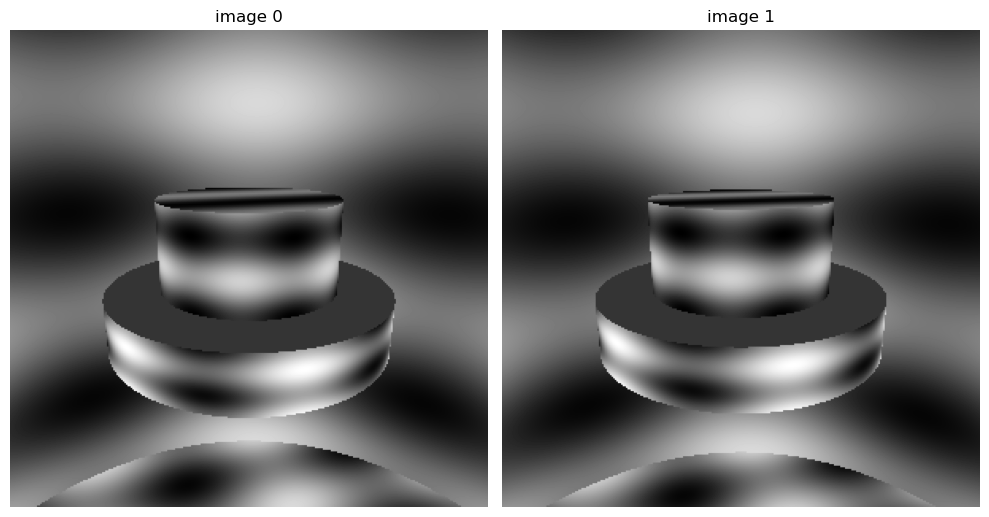

```python
show_image_pair(image_0, image_1)
```

```python
d = displacement(frame_number_0, frame_number_1, camera, world)
```

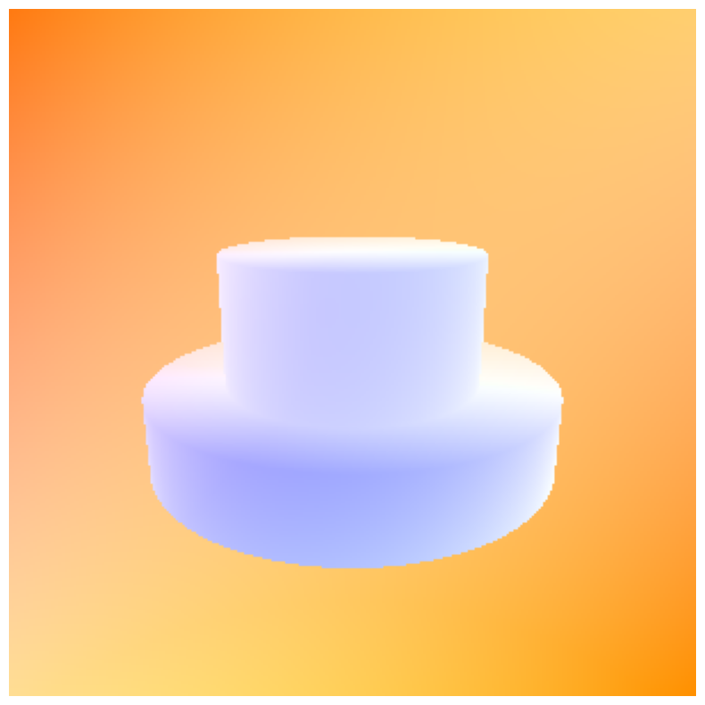

```
Statistics of the displacement magnitude:
minimum: 0.06457, maximum: 12.59, mean absolute value: 6.45, standard deviation: 2.505
```

```python
displacement_image = show_field(d)
stats(np.linalg.norm(d, axis=2), 'displacement magnitude')
```

### Problem 2.1 (Exam Style, Except for the Code)

This problem presents a puzzle that you are asked to explain.

The sampling grid (location of the pixel centers) in frame 0 can be retrieved as follows:

```python
grid_0 = camera.image_grid()
```

This is a $301\times 301\times 2$ array with the $x$ (`grid_0[:, :, 0]`) and $y$ (`grid_0[:, :, 1]`) coordinates of each pixel in the image. The displacement field `d` computed earlier gives the motion between frame 0 and frame 1 for every pixel position in frame 0, and therefore the new point positions in frame 1 are computed as follows:

```python
grid_1 = grid_0 + d
```

Suppose now that we take the points in `grid_1` and we determine their displacements back to frame 0. This can be done with the optional parameter `grid` in the function `displacement`:

```python
d_back = displacement(frame_number_1, frame_number_0, camera, world, grid=grid_1)
```

Note the reverse order for the first two arguments: We are computing displacements going back in time.

We can now recompute the original grid:

```python
grid_back = grid_1 + d_back
```

You could reasonably expect that `grid_back` and `grid_0` are effectively the same grid, since we track points forward in time (using their true displacements, so no errors here!) and then back in time again (ditto).

However, if we plot the end-point error field between these two grids we obtain the following:

[figure not shown]

```python
fb_epe = grid_back - grid_0
fb_epe_image = show_field(fb_epe)
```

Explain clearly which points are painted orange in the plot above. Try to explain what happened to the extent that you can.

#### Hint

The function `displacement` works as follows to compute the motion for each image point $\mathbf{p}$ in frame 0:

- It figures out what point $\mathbf{P}$ in the world image point $\mathbf{p}$ corresponds to. That is, $\mathbf{p}$ is the projection of $\mathbf{P}$, as computed from the laws of perspective projection, and as if $\mathbf{P}$ were the only point in the world.
- It moves the world point $\mathbf{P}$ by accounting for the true relative motion between camera and $\mathbf{P}$ between frame 0 and frame 1, to find a new world point $\mathbf{Q}$.
- It projects the world point $\mathbf{Q}$ back to the image to find the point $\mathbf{q}$ in frame 1 that corresponds to point $\mathbf{p}$ in frame 0. Again this is done via the laws of perspective projection, and as if $\mathbf{Q}$ were the only point in the world.
- It returns the displacement vector $\mathbf{d} = \mathbf{q} - \mathbf{p}$.

## Part 3: The Lucas-Kanade Tracker

The code below retrieves a simple implementation of the Lucas-Kanade (LK) tracker. You may want to peruse the file `LK.py` if you have any lingering doubts about what the algorithm does after studying the class notes.

```python
retrieve('LK.py')
```

```
Downloaded file LK.py
```

Let us track four points in noisy versions of the images `image_0` and `image_1` we made earlier in Part 2. The points are numbered 0 through 3 by where they show up in the tuple `points_and_window_sizes`. We examine how the LK tracker does on each of them with the following code, which compares estimated displacements with the true values we computed earlier and are found in array `d`.

```python
from LK import default_parameters, show_parameters, track_and_compare

show_parameters(default_parameters, 'default ')

sigma = 0.01
noisy_0 = image_0 + sigma * np.random.random(image_0.shape)
noisy_1 = image_1 + sigma * np.random.random(image_1.shape)
```

```
Lucas-Kanade tracker default parameters:
	gaussian window size: 5
	feature window size: 31
	smallest acceptable step: 0.001
	maximum number of iterations: 100
```

```
tracking of point 0: [150, 107] with window size 11 failed
point 1: [100, 120] -> [ 99.683 118.435], window size 11
	computed displacement: [-0.317 -1.565]
	true displacement: [-0.277 -1.577]
	end-point error: 0.042 pixels
point 2: [150, 150] -> [148.176 147.696], window size 11
	computed displacement: [-1.824 -2.304]
	true displacement: [-1.509 -2.26 ]
	end-point error: 0.318 pixels
tracking of point 3: [150, 193] with window size 11 failed
```

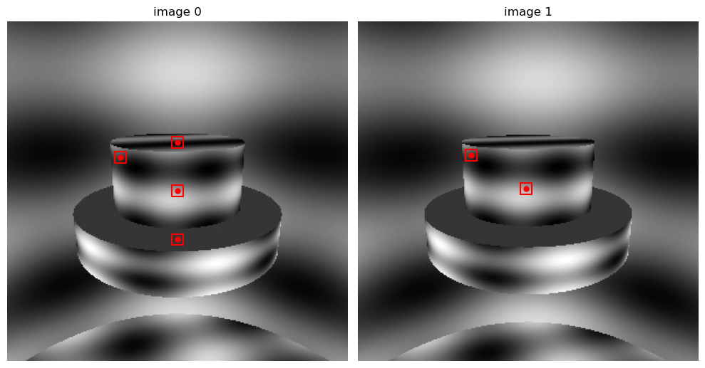

```python
points_and_window_sizes = (
    ([150, 107], 11),
    ([100, 120], 11),
    ([150, 150], 11),
    ([150, 193], 11)
)
track_and_compare(noisy_0, noisy_1, points_and_window_sizes, d)
```

The `gaussian window size` is the size of the kernel used for differentiation. The `feature window size` is the size of the tracking window. The other two LK parameters are used to determine convergence.

Each point in `points_and_window_sizes` comes with a window size, currently set to 11 for all points. This value determines the `feature window size` for that point before it is tracked.

### Problem 3.1 (Exam Style)

Of course, results can vary somewhat since noise is random. However, points 0 and 3 are typically not tracked successfully. Explain briefly why not, separately for each of them, and referring to the images and to the matrix $A$ of the system that the Newton-Raphson method solves at each iteration.

### Problem 3.2 (Exam Style Except for the Code)

Change the window size for points 1, 2 to, say, 31. Leave the other window sizes at 11 and do *not* remake the images `noisy_0` or `noisy_1`. Does the tracker do better with the larger window sizes? Why or why not? Discuss for each of these two points separately.

There is no need to refer to the matrix $A$ in your explanations. However, do refer to the major ways in which window size influences tracking accuracy.

## Part 4: Good Features to Track

Knowing that the Lucas-Kanade tracker is used for tracking points between two video frames yields a principled way to determine points in the first frame that can be tracked well, even without knowing what the second frame looks like. Points that can be tracked well are minimally affected by the aperture problem. The general idea is as follows:

- Lucas-Kanade uses Newton-Raphson to track a point centered at $\mathbf{x}_f$ in frame $f$ (the first of two frames $f$, $f'$). This optimization technique is used to minimize the Sum of Squared Differences (SSD) between pairs of windows, one in $f$ and the other in $f'$, as a function of the displacement $\mathbf{d}$ between the two windows.
- The basic iteration of Newton-Raphson solves a $2\times 2$ linear system $A(\mathbf{x}_{f'})\mathbf{d} = \mathbf{b}$ where the matrix $A(\mathbf{x}_{f'})$ is computed on a shifted version of $f'$.
- Once the correct displacement is found, a window in the shifted frame $f'$ will look very similar to the corresponding window in frame $f$, since the shift is computed so that the two windows correspond.
- So we can compute $A(\mathbf{x}_f)$ for all pixel positions $\mathbf{x}_f$ in $f$, rather than in $f'$. We don't even need to know $f'$ to do this. With small motions, the matrices $A(\mathbf{x}_{f'})$ encountered in Newton-Raphson are likely quite similar to each other and to $A(\mathbf{x}_{f})$.
- The idea for finding good features is that Newton-Raphson will work reliably if the matrix $A(\mathbf{x}_f)$ is well-conditioned, so that the linear systems that Newton-Raphson needs to solve have unique solutions. A matrix is well-conditioned if its smaller eigenvalue is not too small (that is, the matrix is far from rank 1). Thus, pixels $\mathbf{x}_f$ for which the smaller eigenvalue of the matrix $A(\mathbf{x}_f)$ is large are good features to track.
- The expression for $A(\mathbf{x}_f)$ is as follows, where $W(\mathbf{x}_f)$ is a square window of shape $(2h+1, 2h+1)$ pixels centered at $\mathbf{x}_f$, and where $\mathbf{g}(\mathbf{x}) = \nabla f(\mathbf{x})$ is the gradient of $f$ at $\mathbf{x}$. To keep things simple, no weight function is used.

$$ A(\mathbf{x}_f) = \sum_{\mathbf{x}\in W(\mathbf{x}_f)} \mathbf{g}(\mathbf{x}) \mathbf{g}(\mathbf{x})^T \;. $$

- A window $W(\mathbf{x}_f)$ centered at $\mathbf{x}_f$ is a good feature to track if the following conditions are met:
  1. *Feature quality:* The smaller eigenvalue of $A(\mathbf{x}_f)$ is above some given positive threshold $\tau$.
  2. *Sparse feature distribution:* If a good feature exists at $\mathbf{x}_f$, no other good feature is chosen within some given minimum Euclidean distance $d_{\min}$ pixels from $\mathbf{x}_f$.
  3. *Efficiency:* There are at most $n_{\max}$ good features in $f$, where $n_{\max}$ is a given integer.
- Of course, $\mathbf{x}_f$ cannot be too close to the image boundaries, or else $W(\mathbf{x}_f)$ will exceed the boundaries.

### Problem 4.1

Write code that finds good features to track in the first of two video frames along the idea explained above.

Specifically, write a function with header

```
def good_features(image, h, tau, d_min, n_max, sigma=2.):
```

where `image` is a `numpy` array containing a black-and-white image and `h`, `tau`, `d_min`, and `n_max` are $h$, $\tau$, $d_{\min}$, and $n_{\max}$ as defined above. The parameter `sigma`, which you will leave at its default value, is the $\sigma$ to use when differentiating an image.

Then show the features resulting from running the commands

```
half_window, min_ev, min_distance, n = 5, 0., 25, 300
features = good_features(frame.astype(float), half_window, min_ev, min_distance, n)
```

where the image `frame` is downloaded below.

To display the results, show the image and place a visible red dot at every feature position.

```python
import skimage as sk


name = 'fauci_0.png'
retrieve(name)
frame = sk.io.imread(name)
```

```
Downloaded file fauci_0.png
```

#### Programming Notes

For full credit, your code must comply with the following notes:

- Compute the image gradient by convolving with Gaussians and their derivatives as shown in the class notes *and using separability.* For a Gaussian with parameter $\sigma$, make the kernel half-length $h_{\sigma} = \text{round}(3.5\sigma)$ so that the kernel length is $\ell = 2 h_{\sigma} + 1$ (for both differentiator and smoother). Use `'valid'` convolutions (so the gradient is smaller than the input image). Use the function `scipy.signal.convolve2d`.
- Use no `for` loops on image pixels in your code, or else your code would be hopelessly slow. To this end, note that the matrix $A$ is $2\times 2$ and symmetric, so it has three distinct entries. Let us call those $a_{11}, a_{12}, a_{22}$. Then $a_{21}$ is the same as $a_{12}$, so it does not need to be computed. To compute, say, $a_{12} = \sum_{\mathbf{x}\in W(\mathbf{x}_f)} g_1(\mathbf{x}) g_2(\mathbf{x})$ use a `numpy` array operation to compute the product $g_1g_2$ everywhere. Then, use the fact that the summation is a separable convolution. This is the case for any summation of the form $\sum_{\mathbf{x}\in W(\mathbf{x}_f)} p(\mathbf{x})$ where $W(\mathbf{x}_f)$ is a window. The fact that $p$ is a product is irrelevant. (You may have to think a bit to see how that is a convolution, and why it is separable.) Use `'valid'` convolutions (so the resulting arrays are smaller than the gradient arrays).
- Once you have $a_{11}, a_{12}, a_{22}$ everywhere (as three `numpy` arrays or, if you prefer, as a single $r\times c\times 3$ array), you can compute eigenvalues using the closed-form formula for eigenvalues of a symmetric $2\times 2$ matrix. Feel free to look that up.
- Since both eigenvalues need to be at least $\tau$, all you need to compute is the smaller of the two (the one with the minus sign!). The smaller eigenvalue can be computed everywhere all at once with `numpy` array operations using the formula.
- Make row, column indices for all the image entries corresponding to the eigenvalue entries. The indices refer to the full image, but the eigenvalue array is only part of it because of the `'valid'` convolutions. You may want to make a helper function to compute these indices.
- Now you have the row, column locations and corresponding eigenvalues for all the window centers $\mathbf{x}_f$ with sufficiently large eigenvalues (condition 1). To satisfy conditions 2 and 3, sort the pixels in order of decreasing eigenvalue (as you sort eigenvalues, reorder the corresponding row, column indices as well). Put the item that is at the top of the sorted list in the final set of good features. Remove all points in the list that are closer than $d_{\min}$ to the top item to enforce condition 2 (this can be done with `numpy` array operations without explicit `for` loops). Repeat using a loop `for k in range(n_max)` or something equivalent. This will enforce condition 3, and should be the only explicit `for` loop in your code.
- Structure your code cleanly with helper functions for readability.

#### Display Format

- Use `matplotlib.pyplot.imshow` to display the image with `cmap='gray'` and `axis('off')`.
- Use `matplotlib.pyplot.plot` to place a well-visible red dot at each selected pixel (no explicit `for` loops needed here).

## Part 5: Basic Vector Geometry

Let $\mathbf{a} = (3, 2, 6)^T$, $\mathbf{b} = (4, 0, 5)^T$, and $\mathbf{c}$ be the cross product of $\mathbf{a}$ and $\mathbf{b}$ .

### Problem 5.1 (Exam Style)

Give an exact numerical expression for $\mathbf{c}$.

### Problem 5.2 (Exam Style)

Give exact numerical expressions for the projection $\mathbf{d}$ of $\mathbf{a}$ onto $\mathbf{b}$ and the projection $\mathbf{e}$ of $\mathbf{b}$ onto $\mathbf{a}$.

#### Note

Both $\mathbf{d}$ and $\mathbf{e}$ are vectors.

### Problem 5.3 (Exam Style)

Consider the matrix

$$ A = \frac{1}{4}\ \left[\begin{array}{ccc} 2 \sqrt{3} & 2 & 0 \\ \sqrt{3} & -3 & 2 \\ -1 & \sqrt{3} & 2 \sqrt{3} \end{array}\right] \;. $$

For each of the matrices $A$ and $-A$, state whether the matrix is a rotation and justify your answer.